# Perkolacja_Siec_Kwadrat

### Perkolacja na sieci kwadratowej

```python
import random
import numpy as np
L=10
Lm1=L-1
siec=np.zeros((L,L),int)
p=0.65
#losowa obsada sieci
zielone=[] #lista współrzędnych obsadzonych węzłów

for k in range (0,L):
    for i in range(0,L):
        if random.random()<p:
            siec[k,i]=-1
            zielone.append([k,i])
            #licz=licz+1
print(len(zielone))
#zamiana listy na tablicę
ziel_grf=np.asarray(zielone)
```

```
59
```

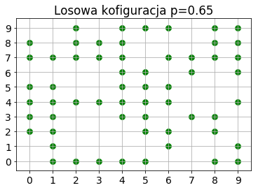

```python
%matplotlib  inline
import matplotlib.pyplot as plt
plt.rcParams.update({'font.size': 14})
fig, ax = plt.subplots()
ax.set_xticks(np.arange(0,L,1))
ax.set_yticks(np.arange(0,L,1))
tyt="Losowa kofiguracja p="+str(p)
ax.set_title(tyt)
ax.grid()
atomy=ax.scatter(ziel_grf[:,0],ziel_grf[:,1],s=60,c='g')
plt.show()
```

```python
# Wypalanie - rozprzestrzenianie czerwonego koloru
czerwone=[] # początkowo zielone z pierwszej kolumny
czarne=[]   # czerwone zamieniają się w czarne

for i in range(0,L):
    if siec[0,i]==-1:
        czerwone.append([0,i]) #dodajemy do czerw
        zielone.remove([0,i])  #usuwamy z zielonych
        siec[0,i]=1            #zmiana statusu wezła

#czarne.append(czerwone[0])

def krok_propag(sc,ziel,czerw,czar):
    tymcz=[]
    for wz in czerw:
        czar.append([wz[0],wz[1]])
        #sprawdzenie czy sąsiedzi są zieloni
        #musimy uważać aby nie przekroczyć zakresu sieci
        if wz[0]>0 and sc[wz[0]-1,wz[1]]==-1: #(-1,0)
            tymcz.append([wz[0]-1,wz[1]])
            ziel.remove([wz[0]-1,wz[1]])
            sc[wz[0]-1,wz[1]]=1
        if wz[0]<Lm1 and sc[wz[0]+1,wz[1]]==-1: #(1,0)
            tymcz.append([wz[0]+1,wz[1]])
            ziel.remove([wz[0]+1,wz[1]])
            sc[wz[0]+1,wz[1]]=1
        if wz[1]>0 and sc[wz[0],wz[1]-1]==-1: #(0,-1)
            tymcz.append([wz[0],wz[1]-1])
            ziel.remove([wz[0],wz[1]-1])
            sc[wz[0],wz[1]-1]=1
        if wz[1]<Lm1 and sc[wz[0],wz[1]+1]==-1: #(0,1)
            tymcz.append([wz[0],wz[1]+1])
            ziel.remove([wz[0],wz[1]+1])
            sc[wz[0],wz[1]+1]=1
    return tymcz

def obraz_wyp(ziel,czerw,czar,krok) :
    z_grf=np.asarray(ziel)
    e_grf=np.asarray(czerw)
    fig, ax = plt.subplots()
    ax.set_xticks(np.arange(0,L,1))
    ax.set_yticks(np.arange(0,L,1))
    tyt="krok="+str(krok)
    ax.set_title(tyt)
    ax.grid()
    gz=ax.scatter(z_grf[:,0],z_grf[:,1],s=60,c='g')
    ge=ax.scatter(e_grf[:,0],e_grf[:,1],s=60,c='r')
    if len(czar)>1:
        a_grf=np.asarray(czar)
        ga=ax.scatter(a_grf[:,0],a_grf[:,1],s=30,c='k')

    plt.show()
```

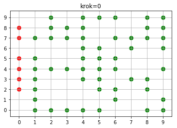

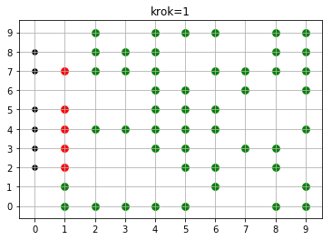

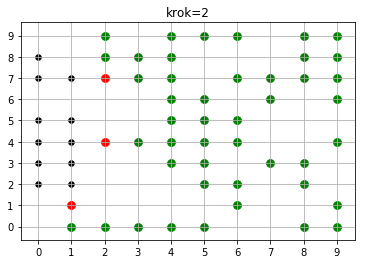

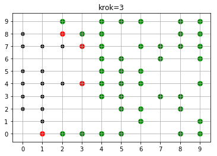

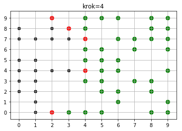

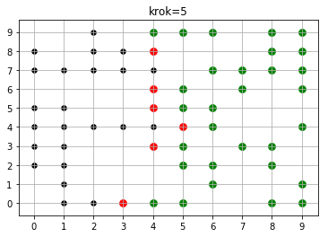

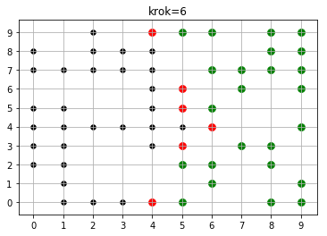

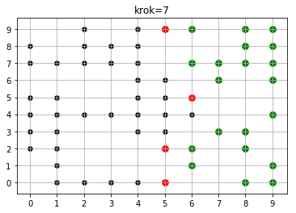

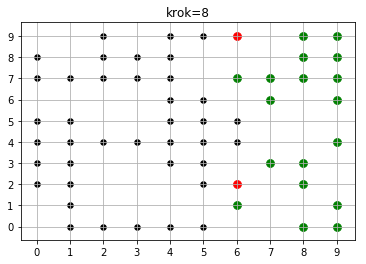

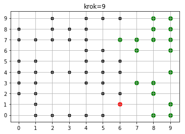

```python
 #ewolucja rozprzestrzeniania koloru czerwonego
t=0
while len(czerwone)>0:
    obraz_wyp(zielone,czerwone,czarne,t)
    czerwone=krok_propag(siec,zielone,czerwone,czarne)
    t=t+1
```

### Czasy wypalania

Wygenerujemy losową konfigurację z prawdopodobieństwem p obsadzenia węzła sieci. Obliczymy czas wypalenia, czyli liczbę kroków czasowych potrzebną do zakończenia wypalania

```python
import random
import numpy as np

def init(p,sc):
    #losowa obsada sieci
    for k in range (0,L):
        for i in range(0,L):
            if random.random()<p:
                sc[k,i]=-1
            else:
                sc[k,i]=0
    czerw=[]
    for i in range(0,L):
        if sc[0,i]==-1:
            czerw.append([0,i]) #dodajemy do czerw
            sc[0,i]=1
    return czerw

def krok_propag(sc,czerw):
    tymcz=[]
    for wz in czerw:
        if wz[0]>0 and sc[wz[0]-1,wz[1]]==-1: #(-1,0)
            tymcz.append([wz[0]-1,wz[1]])
            sc[wz[0]-1,wz[1]]=1
        if wz[0]<Lm1 and sc[wz[0]+1,wz[1]]==-1: #(1,0)
            tymcz.append([wz[0]+1,wz[1]])
            sc[wz[0]+1,wz[1]]=1
        if wz[1]>0 and sc[wz[0],wz[1]-1]==-1: #(0,-1)
            tymcz.append([wz[0],wz[1]-1])
            sc[wz[0],wz[1]-1]=1
        if wz[1]<Lm1 and sc[wz[0],wz[1]+1]==-1: #(0,1)
            tymcz.append([wz[0],wz[1]+1])
            sc[wz[0],wz[1]+1]=1
    return tymcz
```

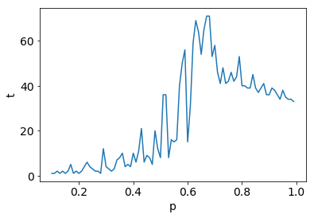

```python
L=32
Lm1=L-1
siec=np.zeros((L,L),int)
czas=[]
prob=[]
for p in np.arange(0.1,1,0.01):
    t=0
    czerwone=init(p,siec)
    while len(czerwone)>0:
        czerwone=krok_propag(siec,czerwone)
        t=t+1
    prob.append(p)
    czas.append(t)
%matplotlib  inline
import matplotlib.pyplot as plt
plt.rcParams.update({'font.size': 14})
fig, ax = plt.subplots()
cz=ax.plot(prob,czas,label='krzywa')
#ax.legend()
ax.set_ylabel('t')
ax.set_xlabel('p')
plt.show()
    #ewolucja rozprzetrzeniania koloru czerwonego
```

Obserwujemy bardzo duże błędy statystyczne czasów wypalenia. Żeby zredukować te błedy należy, dla każdego p, uśrednić czasy wypalenia po wielu konfiguracjach

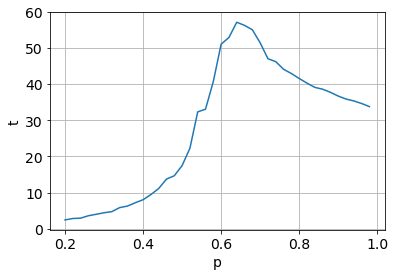

```python
#Uśrednianie po 100 konfiguracjach
L=32
Lm1=L-1
nkonf=100
siec=np.zeros((L,L),int)
czas32=[]
prob32=[]
for p in np.arange(0.2,1,0.02):
#for p in np.arange(0.5,0.7,0.02):
    tav=0
    for k in range(nkonf):
        t=0
        czerwone=init(p,siec)
        while len(czerwone)>0:
            czerwone=krok_propag(siec,czerwone)
            t=t+1
        tav=tav+t
    tav=tav/nkonf
    prob32.append(p)
    czas32.append(tav)

plt.rcParams.update({'font.size': 14})
fig, ax = plt.subplots()

cz=ax.plot(prob32,czas32)
ax.set_ylabel('t')
ax.set_xlabel('p')
ax.grid()
plt.show()
```

Symulacje czasów wypalania dla dużych sieci są czasochłonne. Dlatego warto zapisać wyniki symulacji do pliku, żeby je póżniej analizować.

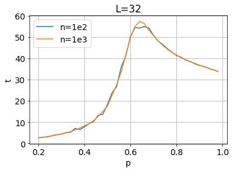

```python
%matplotlib  inline
import matplotlib.pyplot as plt
# wczytanie plików z czasami
wej=open('czas_wyp_32e2.txt','r')
lines=wej.readlines()
wej.close()
xt=[]
yt=[]
for line in lines:
    tym=line.split()
    xt.append(float(tym[0]))
    yt.append(float(tym[1]))
x32_2=np.array(xt)
y32_2=np.array(yt)

wej=open('czas_wyp_32e3.txt','r')
lines=wej.readlines()
wej.close()
xt=[]
yt=[]
for line in lines:
    tym=line.split()
    xt.append(float(tym[0]))
    yt.append(float(tym[1]))
x32_3=np.array(xt)
y32_3=np.array(yt)

# wykres
plt.rcParams.update({'font.size': 14})
fig, ax = plt.subplots()
tyt="L=32"
cz=ax.plot(x32_2,y32_2,label='n=1e2')
cz2=ax.plot(x32_3,y32_3,label='n=1e3')
ax.legend()
ax.set_ylabel('t')
ax.set_xlabel('p')
ax.grid()
ax.set_title(tyt)
plt.show()
```

Prównanie wyników uśredniania po 100 i 1000 konfiguracjach dla sieci $32\times 32$ pokazuje, że dla 100 konfiguracji błędy statytyczne są jeszcze zbyt duże

Zbadamy jak zależą czasy wypalnia od p dla większych sieci. Ograniczymy badanie do przedziału $0.5\le p\le 0.8$, w którym pojawia się maksimum

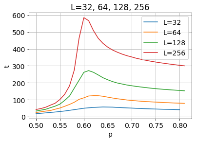

```python
# Zależność od rozmiaru sieci
wej=open('wczas_wyp_64e3.txt','r')
lines=wej.readlines()
wej.close()
xt=[]
yt=[]
for line in lines:
    tym=line.split()
    xt.append(float(tym[0]))
    yt.append(float(tym[1]))
x64_3=np.array(xt)
y64_3=np.array(yt)

wej=open('wczas_wyp_128e3.txt','r')
lines=wej.readlines()
wej.close()
xt=[]
yt=[]
for line in lines:
    tym=line.split()
    xt.append(float(tym[0]))
    yt.append(float(tym[1]))
x128_3=np.array(xt)
y128_3=np.array(yt)

wej=open('wczas_wyp_256e3.txt','r')
lines=wej.readlines()
wej.close()
xt=[]
yt=[]
for line in lines:
    tym=line.split()
    xt.append(float(tym[0]))
    yt.append(float(tym[1]))
x256_3=np.array(xt)
y256_3=np.array(yt)
# wykres

fig, ax = plt.subplots()
tyt="L=32, 64, 128, 256"

cz32=ax.plot(x32_3[15:-9],y32_3[15:-9],label='L=32')
cz64=ax.plot(x64_3,y64_3,label='L=64')
cz128=ax.plot(x128_3,y128_3,label='L=128')
cz256=ax.plot(x256_3,y256_3,label='L=256')
ax.legend()
ax.set_ylabel('t')
ax.set_xlabel('p')
ax.grid()
ax.set_title(tyt)
plt.show()
```

Maksymalny czas wypalania występuje dla $p\approx 0.6$ i gwałtownie rośnie z rozmiarem sieci. Co może być przyczyną tego efektu?

Przeskalowanie czasów wypalania $t_s=\frac{t}{L}$ pozwala łatwiej zauważyć przesmieszczanie się i wyostrzanie piku z rozmiarem L

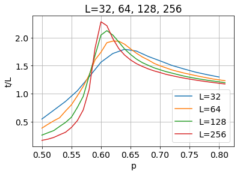

```python
fig, ax = plt.subplots()
tyt="L=32, 64, 128, 256"

cz32=ax.plot(x32_3[15:-9],y32_3[15:-9]/32,label='L=32')
cz64=ax.plot(x64_3,y64_3/64,label='L=64')
cz128=ax.plot(x128_3,y128_3/128,label='L=128')
cz256=ax.plot(x256_3,y256_3/256,label='L=256')
ax.legend()
ax.set_ylabel('t/L')
ax.set_xlabel('p')
ax.grid()
ax.set_title(tyt)
plt.show()
```

### Klastry

Klastrem nazywamy zbiór cząstek z relacją najbliższego sąsiedztwa. Innymi słowy, cząstki będące najbliższymi sąsiadami należą do jednego klatra.

Ile może być klastrów w losowej koniguracji i jak znaleźć kalstry, to kwestie, którymi teraz się zajmiemy

```python
def init(p,sc):
    #losowa obsada sieci
    for k in range (0,L):
        for i in range(0,L):
            if random.random()<p:
                sc[k,i]=-1
            else:
                sc[k,i]=0



def klaster(sc,tkl,num):
    tymcz=[]
    for wz in tkl:
        if wz[0]>0 and sc[wz[0]-1,wz[1]]==-1: #(-1,0)
            tymcz.append([wz[0]-1,wz[1]])
            sc[wz[0]-1,wz[1]]=num
        if wz[0]<Lm1 and sc[wz[0]+1,wz[1]]==-1: #(1,0)
            tymcz.append([wz[0]+1,wz[1]])
            sc[wz[0]+1,wz[1]]=num
        if wz[1]>0 and sc[wz[0],wz[1]-1]==-1: #(0,-1)
            tymcz.append([wz[0],wz[1]-1])
            sc[wz[0],wz[1]-1]=num
        if wz[1]<Lm1 and sc[wz[0],wz[1]+1]==-1: #(0,1)
            tymcz.append([wz[0],wz[1]+1])
            sc[wz[0],wz[1]+1]=1
    return tymcz
```

```
51 51
```

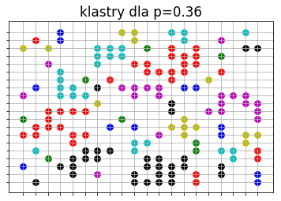

```python
L=20
Lm1=L-1
siec=np.zeros((L,L),int)
p=0.36
num=0
list_klast=[]
init(p,siec)
for i in range(L):
    for k in range(L):
        if siec[i,k]==-1:  # nie nalezy do żadnego klastra
            klast=[]       # współrzędne nowego klastra
            tkl=[]         # front klastra
            num=num+1      # numer nowego klastra
            siec[i,k]=num  # pierwszy węzęł nowego klastra
            tkl.append([i,k])
            while len(tkl)>0:  #dołączanie węzłów metodą wypalania
                klast.extend(tkl)
                tkl=klaster(siec,tkl,num)
                #koniec identyfikacji klastra
            list_klast.append(klast) #dodanie do listy klastrów

print(num, len(list_klast))
licol=('b','r','g','m','y','k','c')
fig, ax = plt.subplots()
ax.set_xticks(np.arange(0,L,1))
ax.set_yticks(np.arange(0,L,1))
ax.set_xticklabels([])
ax.set_yticklabels([])
tyt="klastry dla p="+str(p)
ax.set_title(tyt)
ax.grid()
for i in range (len(list_klast)):
    #print(len(list_klast[i]))
    k_grf=np.asarray(list_klast[i])
    gk=ax.scatter(k_grf[:,0],k_grf[:,1],s=60,c=licol[i%7])

plt.show()
```

```
33 33
```

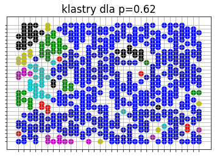

```python
#klaster perkolacyjny
L=32
Lm1=L-1
siec=np.zeros((L,L),int)
p=0.62
num=0
list_klast=[]
init(p,siec)
for i in range(L):
    for k in range(L):
        if siec[i,k]==-1:
            klast=[]
            tkl=[]
            num=num+1
            siec[i,k]=num
            tkl.append([i,k])
            while len(tkl)>0:
                klast.extend(tkl)
                tkl=klaster(siec,tkl,num)
            list_klast.append(klast)

print(num, len(list_klast))
licol=('b','r','g','m','y','k','c')
fig, ax = plt.subplots()
ax.set_xticks(np.arange(0,L,1))
ax.set_yticks(np.arange(0,L,1))
ax.set_xticklabels([])
ax.set_yticklabels([])
tyt="klastry dla p="+str(p)
ax.set_title(tyt)
ax.grid()
for i in range (len(list_klast)):
    #print(len(list_klast[i]))
    k_grf=np.asarray(list_klast[i])
    gk=ax.scatter(k_grf[:,0],k_grf[:,1],s=60,c=licol[i%7])

plt.show()
```

```python
#Sprawdzenie czy jest klaster w danej konfiguracji
# metoda wypalania do czasu osiągnięcia przeciwległego brzegu
L=32
Lm1=L-1
siec=np.zeros((L,L),int)
p=0.60
def init_siec(p,sc):
    #losowa obsada sieci
    for k in range (0,L):
        for i in range(0,L):
            if random.random()<p:
                sc[k,i]=-1
            else:
                sc[k,i]=0
    zainfek=[]
    for i in range(0,L):
        if sc[0,i]==-1:
            zainfek.append([0,i]) #dodajemy do zainfek
            sc[0,i]=1
    return zainfek

def krok_propag(sc,czerw):
    tymcz=[]
    jest=0
    for wz in czerw:
        if wz[0]>0 and sc[wz[0]-1,wz[1]]==-1: #(-1,0)
            tymcz.append([wz[0]-1,wz[1]])
            sc[wz[0]-1,wz[1]]=1
        if wz[0]<Lm1 and sc[wz[0]+1,wz[1]]==-1: #(1,0)
            tymcz.append([wz[0]+1,wz[1]])
            sc[wz[0]+1,wz[1]]=1
            if (wz[0]+1)==Lm1:               #czy dotarł do brzegu
                jest=1
                break
        if wz[1]>0 and sc[wz[0],wz[1]-1]==-1: #(0,-1)
            tymcz.append([wz[0],wz[1]-1])
            sc[wz[0],wz[1]-1]=1
        if wz[1]<Lm1 and sc[wz[0],wz[1]+1]==-1: #(0,1)
            tymcz.append([wz[0],wz[1]+1])
            sc[wz[0],wz[1]+1]=1
    return jest,tymcz
```

```python
for p in np.arange(0.5,0.7,0.02):
    tymkl= init_siec(p,siec)
    link=0
    while len(tymkl)>0 and link==0:
        link,tymkl,=krok_propag(siec,tymkl)
    if link==1:
        print(p,'JEST')
    else:
        print(p,'nie ma')
```

```
0.5 nie ma
0.52 nie ma
0.54 nie ma
0.56 nie ma
0.5800000000000001 nie ma
0.6000000000000001 JEST
0.6200000000000001 nie ma
0.6400000000000001 JEST
0.6600000000000001 JEST
0.6800000000000002 JEST
```

```python
#prog perkolacji
#dla jakiego p pojawi się klaster perkolacyjny
#uśrednimy po wielu konfiguracjach z losowym p
```

```python
nmc=1
for _ in range(4):
    nmc=nmc*10
    pav=0                    #średnia wart. progu perkolacji
    for i in range(nmc):
        p=random.random()
        tymkl= init_siec(p,siec)
        link=0
        while len(tymkl)>0 and link==0:
            link,tymkl,=krok_propag(siec,tymkl)
        if link==0: #teraz SUKCES jeśli nie ma klastra perkolac.
            pav=pav+1
    pav=pav/nmc
    print(pav,nmc)
```

```
0.4 10
0.63 100
0.568 1000
0.589 10000
```

```python
#czy wynik zależy od rozmiaru sieci?

nmc=10000
for L in range(10,105,10):
    Lm1=L-1
    siec=np.zeros((L,L),int)
    pav=0                    #średnia wart. progu perkolacji
    for i in range(nmc):
        p=random.random()
        tymkl= init_siec(p,siec)
        link=0
        while len(tymkl)>0 and link==0:
            link,tymkl,=krok_propag(siec,tymkl)
        if link==0: #teraz SUKCES jeśli nie ma klastra perkolac.
            pav=pav+1
    pav=pav/nmc
    print(L,pav)
```

```
10 0.5864
20 0.5894
30 0.5935
40 0.5867
50 0.5945
60 0.5918
70 0.5956
80 0.5958
90 0.5853
100 0.5886
```

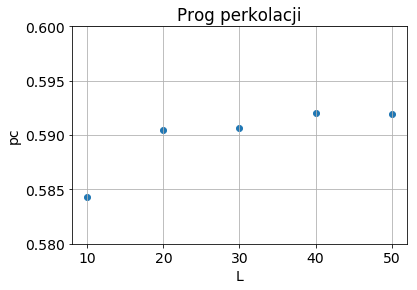

```
[10. 20. 30. 40. 50.]
[0.584308 0.590449 0.590667 0.592065 0.591974]
```

```python
# żeby zmniejszyć błędy statystyczne obliczenia dla 10^6 konfiguracji
# wczytane plików z progami dla L=10,20,...,50
wej=open('prog_SQ_e6.txt','r')
lines=wej.readlines()
wej.close()
xt=[]
yt=[]
for line in lines:
    tym=line.split()
    xt.append(float(tym[0]))
    yt.append(float(tym[1]))
tL_5=np.array(xt)
prog_5=np.array(yt)

fig, ax = plt.subplots()
tyt="Prog perkolacji"
ax.scatter(tL_5,prog_5)
ax.set_ylabel('pc')
ax.set_ylim(bottom=0.58, top=0.6)
ax.set_xlabel('L')
ax.grid()
ax.set_title(tyt)
plt.show()
print(tL_5)
print (prog_5)
```